# Clase 5

Strings y Fechas

Barriola y Dotta

16/7/2019

#### Cargamos las librerías a utilizar

```r
library(tidyverse) #siempre lo tenemos a mano
library(stringr) #para trabajar con strings
library(lubridate) #para trabajar con fechas
```

# Lubridate: Manejo de fechas

El paquete lubridate está pensado para trabajar con los datos tipo fecha(date) o fecha-hora(datetime) para cambiarles el formato, realizar operaciones y extraer información.

La [cheatsheet](https://rawgit.com/rstudio/cheatsheets/master/lubridate.pdf) muestra todas las cosas que se pueden hacer con este paquete

### Cambio de formato

Existe una gran cantidad de funciones para realizar esto. La idea general es poder llevar los objetos datetime a un formato común compuesto de los elementos: año, mes, día, hora, minuto y segundo (también se puede setear el huso horario)

```r
fecha  <- "29/09/93 17:35:16"
fecha
```

```
[1] "29/09/93 17:35:16"
```

```r
# Clase de dato
class(fecha)
```

```
[1] "character"
```

Con la función dmy_hms podemos convertir este string a una fecha: estamos indicando que el formato de la fecha es día(d), mes(m), año(y), hora(h), minuto(m) y segundo(s)

```r
fecha  <- dmy_hms(fecha)
fecha
```

```
[1] "1993-09-29 17:35:16 UTC"
```

```r
# Clase de dato
typeof(fecha)
```

```
[1] "double"
```

Muchas funciones de lubridate operan con esta misma lógica

Otra función para realizar un cambio de formato es *parse_date_time*. Permite construir objetos datetime a partir de datos más complejos, como por ejemplo cuando aparece el nombre del mes y el año.

En el parámetro *x* pasamos el dato de la fecha y en el parámetro *orders* especificamos el orden en el cual se encuentra la información de la fecha

```r
fecha2  <- "Sep-93"
fecha2 <- parse_date_time(fecha2, orders = 'my')
fecha2
```

```
[1] "1993-09-01 UTC"
```

### Extracción de información

Existen muchas funciones muy sencillas para extraer información de un objeto datetime. Algunas son

```r
# Obtener el año
year(fecha)
```

```
[1] 1993
```

```r
#Obtener el semestre
semester(fecha)
```

```
[1] 2
```

```r
#Obtener el trimestre
quarter(fecha)
```

```
[1] 3
```

```r
#Obtener el mes
month(fecha)
```

```
[1] 9
```

```r
# Obtener el día
day(fecha)
```

```
[1] 29
```

```r
# Obtener la fecha
date(fecha)
```

```
[1] "1993-09-29"
```

```r
# Obtener el dia de la semana
wday(fecha)
```

```
[1] 4
```

```r
#Obtener el nombre del día
wday(fecha, label = TRUE)
```

```
[1] mié
Levels: dom < lun < mar < mié < jue < vie < sáb
```

```r
#Obtener la hora
hour(fecha)
```

```
[1] 17
```

### Operaciones

Podemos sumar o restarle cualquier período de tiempo a un objeto datetime

```r
# Sumo dos días
fecha + days(2)
```

```
[1] "1993-10-01 17:35:16 UTC"
```

```r
# Resto 1 semana y dos horas
fecha - (weeks(1) + hours(2))
```

```
[1] "1993-09-22 15:35:16 UTC"
```

# Stringr: manejo de strings

Vamos a usar un paquete muy útil para manejar variables de tipo `string`, es decir, variables de texto, llamado `stringr`. Primero vamos a ver algunos de los principales comandos y luego vamos a ver algunos ejemplos un poco más complejos de cómo podemos usar las funciones de este paquete.

Tal como vimos para `ggplot2`, el paquete `stringr` cuenta con una cheat sheet que pueden consultar siguiendo este [link](http://edrub.in/CheatSheets/cheatSheetStringr.pdf).

## Principales funciones

### str_length

Con la función `str_length()` podemos ver el largo de un string.

```r
string1 <- "abcdefghi"
str_length(string1)
```

```
[1] 9
```

Ojo que cuenta los espacios en blanco como un caracter.

```r
string2 <- "abcd efghi"
str_length(string2)
```

```
[1] 10
```

### str_sub

La función `str_sub()` nos permite extraer los caracteres que se encuentran entre determinadas posiciones. Tiene tres argumentos: el string, el orden del caracter a partir del cual tiene que empezar a extraer y el orden del caracter hasta el cual tiene que extraer.

```r
#quiero el tercer caracter
str_sub(string1,3,3)
```

```
[1] "c"
```

```r
#quiero el cuarto y quinto caracter
str_sub(string1,4,5)
```

```
[1] "de"
```

Puedo pasarle la posición de los caracteres con un menos para indicar que quiero que cuente de atrás para adelante. Por ejemplo, si quiero que traiga el anteúltimo caracter llamo a la posición como `-2`.

```r
#quiero la última y anteúltima posición
str_sub(string1,-2,-1)
```

```
[1] "hi"
```

Otro uso que le podemos dar a este comando es el de reemplazar elementos. Supongamos que quiero reemplazar la última letra por una z.

```r
str_sub(string1,-1,-1) <- "z"
string1
```

```
[1] "abcdefghz"
```

### Manejo de espacios en blanco

Es frecuente que aparezcan datos mal cargados o con errores de tipeo que tienen espacios donde no debería haberlos. La función `str_trim()` permite que nos deshagamos de los espacios en blanco a izquierda, derecha o ambos lados de nuestro string.

```r
string3 <- c("  acelga   ", "brocoli   ",  "   choclo")
#Veamos el string
string3
```

```
[1] "  acelga   " "brocoli   "  "   choclo"
```

Quitamos los espacios en blanco a ambos lados con el argumento side=‘both’

```r
str_trim(string3, side = 'both')
```

```
[1] "acelga"  "brocoli" "choclo"
```

Quitamos los espacios en blanco del lado izquierdo con el argumento side=‘left’

```r
str_trim(string3, "left")
```

```
[1] "acelga   "  "brocoli   " "choclo"
```

### Mayúsculas y minúsculas

Existen varias funciones para manipular las mayusculas/minúsculas de nuestros strings. A modo de sugerencia, siempre es convientiente manejarse con todos los caracteres en minúscula o en mayúscula. Esto ayuda a normalizar la información para armar mejor grupos, joinear tablas, etc.

```r
string4 <- "No me gusta el frio"
string4
```

```
[1] "No me gusta el frio"
```

```r
#llevo todo a minúsculas
str_to_lower(string4)
```

```
[1] "no me gusta el frio"
```

```r
#llevo todo a mayúsculas
str_to_upper(string4)
```

```
[1] "NO ME GUSTA EL FRIO"
```

```r
#llevo a mayúscula la primer letra de cada palabra
str_to_title(string4)
```

```
[1] "No Me Gusta El Frio"
```

### str_split

La función `str_split()` nos permite partir un string de acuerdo a algún separador/patron (pattern) que definamos.

```r
#quiero separar todas las letras de mi string
string1_separado <- str_split(string1,pattern = "")
string1_separado
```

```
[[1]]
[1] "a" "b" "c" "d" "e" "f" "g" "h" "z"
```

Notemos que esta funcion nos devuelve una lista

```r
class(string1_separado)
```

```
[1] "list"
```

```r
# Si queremos acceder al primer elemento de la lista
string1_separado[[1]][1]
```

```
[1] "a"
```

Definimos un nuevo string

```r
string5 <- "ab-cd-ef"
string5
```

```
[1] "ab-cd-ef"
```

Lo separamos por el guion

```r
str_split(string5,pattern="-")
```

```
[[1]]
[1] "ab" "cd" "ef"
```

### Reemplazar elementos de strings

La función base `gsub()` nos permite reemplazar parte del string por otra cosa. Las funciones `str_replace()` y `str_replace_all()` de `stringr` nos permiten hacer lo mismo.

`str_replace` solo reemplaza la primera ocurrencia del patron mientras que `str_replace_all()` reemplaza todas las ocurrencias

```r
string6 <- "todos los caballos blancos"
string6
```

```
[1] "todos los caballos blancos"
```

```r
#le sacamos los espacios
gsub(pattern = " ", replacement = "", x = string6)
```

```
[1] "todosloscaballosblancos"
```

```r
#lo llevamos a lenguaje inclusivo
gsub(pattern = "os", replacement = "xs", x = string6)
```

```
[1] "todxs lxs caballxs blancxs"
```

Con stringr

```r
# Reemplazamos la primera ocurrencia
str_replace(string = string6, pattern = "os", replacement = "xs")
```

```
[1] "todxs los caballos blancos"
```

```r
# Reemplazamos todas las ocurrencias
str_replace_all(string = string6, pattern = "os", replacement = "xs")
```

```
[1] "todxs lxs caballxs blancxs"
```

### Detectar patrones en strings

La función `grepl()` nos permite encontrar expresiones dentro de nuestros strings. Nos reporta `VERDADERO` o `FALSO` de acuerdo a si encuentra la expresión que estamos buscando.

```r
string7 <-c("caño", "baño", "ladrillo")
string7
```

```
[1] "caño"     "baño"     "ladrillo"
```

```r
grepl(pattern = "ñ",x = string7)
```

```
[1]  TRUE  TRUE FALSE
```

La funcion `str_detect()` de `stringr` permite hacer lo mismo.

# Ejemplo práctico

## Ejemplo tiburones

Vamos a ver un ejemplo a partir de una base pública que nos trae información sobre ataques de tiburones en el mundo en distintos momentos. Cada fila corresponde a un ataque.

```r
tiburones <- read.csv("https://raw.githubusercontent.com/dmuba/dmuba.github.io/3005a7a5e8c9db5c188ca22a7b9269c94db8ced7/Practicos/TPs%20Entregables/TP02/Shark_Attack_Data.csv") %>% select(-c(Case.Number.1,Case.Number.2,original.order, X, X.1))
head(tiburones,10)
```

|  | Case.Number | Date | Year | Type | Country | Area | Location | Activity | Name | Sex | Age | Injury | Fatal..Y.N. | Time | Species | Investigator.or.Source | pdf | href.formula | href |
| --- | --- | --- | --- | --- | --- | --- | --- | --- | --- | --- | --- | --- | --- | --- | --- | --- | --- | --- | --- |
| 1 | 2016.03.10 | 10-Mar-2016 | 2016 | Unprovoked | Fiji | Vanua Levu |  | Diving for beche-de-mer | Maika Tabua | M | 45 | FATAL | Y | Afternoon |  | Fiji Sun, 3/12/2016 | 2016.03.10-Tabua.pdf | http://sharkattackfile.net/spreadsheets/pdf_directory/2016.03.10-Tabua.pdf | http://sharkattackfile.net/spreadsheets/pdf_directory/2016.03.10-Tabua.pdf |
| 2 | 2016.03.04 | 04-Mar-2016 | 2016 | Unprovoked | USA | Florida | Ocean Reef Park, Singer Island, Palm Beach County |  | male | M | 12 | Superficial injury to foot | N | Afternoon |  | WPTV. 3/4/2016 | 2016.03.04-OCPark.pdf | http://sharkattackfile.net/spreadsheets/pdf_directory/2016.03.04-OCPark.pdf | http://sharkattackfile.net/spreadsheets/pdf_directory/2016.03.04-OCPark.pdf |
| 3 | 2016.03.03.R | Reported 03-Mar-2016 | 2016 | Unprovoked | AUSTRALIA | South Australia | Wrights Bay | Fishing | Lee Taplin | M |  | Puncture wounds to right calf | N | Midnight | Bronze whaler | 9 News, 3/1/2016 | 2016.03.03.R-Taplin.pdf | http://sharkattackfile.net/spreadsheets/pdf_directory/2016.03.03.R-Taplin.pdf | http://sharkattackfile.net/spreadsheets/pdf_directory/2016.03.03.R-Taplin.pdf |
| 4 | 2016.03.02 | 02-Mar-2016 | 2016 | Unprovoked | BRAZIL | Santa Catarina State | Escalerio Beach Balne\xe1rio Cambori\xfa | Swimming | Rafael Hermes Thomas | M | 41 | Minor injury to head | N |  | Sandtiger shark | Misones Online, 3/4/2016 | 2016.03.02-Thomas.pdf | http://sharkattackfile.net/spreadsheets/pdf_directory/2016.03.02-Thomas.pdf | http://sharkattackfile.net/spreadsheets/pdf_directory/2016.03.02-Thomas.pdf |
| 5 | 2016.02.22 | 22-Feb-2016 | 2016 | Unprovoked | NEW CALEDONIA | South Province | Ricaudy Reef, Noumea | Kite surfing | Adrian * | M | 21 | Puncture wounds to right thigh | N | 19h00 |  | Les Nouvelles Cal\xe9doniennes, 2/23/2016 | 2016.02.22-Noumea.pdf | http://sharkattackfile.net/spreadsheets/pdf_directory/2016.02.22-Noumea.pdf | http://sharkattackfile.net/spreadsheets/pdf_directory/2016.02.22-Noumea.pdf |
| 6 | 2016.02.19 | 19-Feb-2016 | 2016 | Unprovoked | NEW CALEDONIA | South Province | Yate | Spearfishing | male | M | 31 | Forearm bitten | N | 16h00 |  | Les Nouvelles Cal\xe9doniennes, 2/19/2016 | 2016.02.19-NewCaledonia.pdf | http://sharkattackfile.net/spreadsheets/pdf_directory/2016.02.19-NewCaledonia.pdf | http://sharkattackfile.net/spreadsheets/pdf_directory/2016.02.19-NewCaledonia.pdf |
| 7 | 2016.02.12 | 12-Feb-2016 | 2016 | Unprovoked | DOMINICAN REPUBLIC | Altagracia Province | Bavaro Beach, Punta Cana | Wading | Patricia Howe | F |  | Avulsion injury to lower leg | N | 15h00 |  | S. Harris | 2016.02.12-Howe.pdf | http://sharkattackfile.net/spreadsheets/pdf_directory/2016.02.12-Howe.pdf | http://sharkattackfile.net/spreadsheets/pdf_directory/2016.02.12-Howe.pdf |
| 8 | 2016.02.10.R | Reported 10-Feb-2016 | 2016 | Unprovoked | CAYMAN ISLANDS | Grand Cayman | Stingray City Bar | Feeding stingrays? | Richard Branson | M | 65 | Minor injury to wrist from Southern stingray | N |  | No shark involvement | R. Branson | 2016.02.10.R-Branson-stingray.pdf | http://sharkattackfile.net/spreadsheets/pdf_directory/2016.02.10.R-Branson-stingray.pdf | http://sharkattackfile.net/spreadsheets/pdf_directory/2016.02.10.R-Branson-stingray.pdf |
| 9 | 2016.02.10 | 10-Feb-2016 | 2016 | Unprovoked | AUSTRALIA | Tasmania | Nettley Bay | Surfing | male | M |  | No injury, knocked off board | N | 12h30 | 3 m shark | C. Black, GSAF | 2016.02.11-NettleyBay.pdf | http://sharkattackfile.net/spreadsheets/pdf_directory/2016.02.11-NettleyBay.pdf | http://sharkattackfile.net/spreadsheets/pdf_directory/2016.02.11-NettleyBay.pdf |
| 10 | 2016.02.05 | 05-Feb-2016 | 2016 | Unprovoked | AUSTRALIA | Queensland | Stradbroke Island | Walking | female | F | 45 | Foot nipped | N | 13h20 |  | Courier Mail, 2/5/2016 | 2016.02.05-Stradbroke.pdf | http://sharkattackfile.net/spreadsheets/pdf_directory/2016.02.05-Stradbroke.pdf | http://sharkattackfile.net/spreadsheets/pdf_directory/2016.02.05-Stradbroke.pdf |

Vamos a trabajar un poco con la limpieza y la normalización de esta base ya que al juntar datos de distintas fuentes la información no es homogénea por lo que es dificil hacer cualquier tipo de análisis.

### Country

Veamos si existen problemas con la variable del país (Country)

```r
# Creamos una lista con los valores de Country para ver si hay algunos problemas
tiburones %>% select(Country) %>% # Seleccionamos la variable del pais
  mutate(Country=as.character(Country)) %>% # Lo convertimos de factor a string
  arrange(Country) %>% # La ordenamos
  distinct() %>% # Nos quedamos con los valores unicos
  as.list() # La convertimos en lista para que sea mas sencilla de ver
```

```
$Country
  [1] ""                               " PHILIPPINES"                   " TONGA"
  [4] "ADMIRALTY ISLANDS"              "ALGERIA"                        "AMERICAN SAMOA"
  [7] "ANDAMAN / NICOBAR ISLANDAS"     "ANGOLA"                         "ANTIGUA"
 [10] "ARGENTINA"                      "ARUBA"                          "ASIA?"
 [13] "ATLANTIC OCEAN"                 "AUSTRALIA"                      "AZORES"
 [16] "BAHAMAS"                        "BAHREIN"                        "BANGLADESH"
 [19] "BARBADOS"                       "BAY OF BENGAL"                  "BELIZE"
 [22] "BERMUDA"                        "Between PORTUGAL & INDIA"       "BRAZIL"
 [25] "BRITISH ISLES"                  "BRITISH NEW GUINEA"             "BRITISH VIRGIN ISLANDS"
 [28] "BRITISH WEST INDIES"            "BURMA"                          "CANADA"
 [31] "CAPE VERDE"                     "CARIBBEAN SEA"                  "CAYMAN ISLANDS"
 [34] "CENTRAL PACIFIC"                "CEYLON (SRI LANKA)"             "CHILE"
 [37] "CHINA"                          "Coast of AFRICA"                "COLUMBIA"
 [40] "COOK ISLANDS"                   "COSTA RICA"                     "CRETE"
```

[output cut: 55 more lines]

Hay varios problemas, pero veamos dos:

1. Hay algunos nombres que no están en mayúscula
2. Hay algunos nombres que tienen espacios en blanco a izquierda y derecha

Llevamos los nombres a mayúscula

```r
tiburones <- tiburones %>% mutate(pais=str_to_upper(Country))
```

Quitamos los espacios en blanco a izquierda y derecha

```r
tiburones <- tiburones %>% mutate(pais=str_trim(pais, side="both"))
```

### Date

Vamos a empezar analizando la variable `Date` de nuestro dataset. Primero llevamos esta variable a un pequeño dataset aparte y llevamos la variable al tipo `character` para poder manejarla como un string.

```r
Date<-tiburones %>% select(Case.Number, Date) %>% # Seleccionamos las variables de numero de caso y fecha
                    mutate(Date=as.character(Date)) # Tranformamos la fecha en string
glimpse(Date)
```

```
Observations: 5,897
Variables: 2
$ Case.Number <fct> 2016.03.10, 2016.03.04, 2016.03.03.R, 2016.03.02, 2016.02.22, 2016.02.19, 2016.02.12, 20…
$ Date        <chr> "10-Mar-2016", "04-Mar-2016", "Reported 03-Mar-2016", "02-Mar-2016", "22-Feb-2016", " 19…
```

Vemos que la variable `Date` viene en muchos casos con la palabra **Reported** lo cual nos impide que podamos tratar esa expresión como fecha usando las herramientas que vimos en la sección de lubridate.

```r
Date <- Date %>% mutate(date_clean1= str_replace_all(string = Date, pattern =  "Reported ", replacement = ""))
head(Date,10)
```

|  | Case.Number | Date | date_clean1 |
| --- | --- | --- | --- |
| 1 | 2016.03.10 | 10-Mar-2016 | 10-Mar-2016 |
| 2 | 2016.03.04 | 04-Mar-2016 | 04-Mar-2016 |
| 3 | 2016.03.03.R | Reported 03-Mar-2016 | 03-Mar-2016 |
| 4 | 2016.03.02 | 02-Mar-2016 | 02-Mar-2016 |
| 5 | 2016.02.22 | 22-Feb-2016 | 22-Feb-2016 |
| 6 | 2016.02.19 | 19-Feb-2016 | 19-Feb-2016 |
| 7 | 2016.02.12 | 12-Feb-2016 | 12-Feb-2016 |
| 8 | 2016.02.10.R | Reported 10-Feb-2016 | 10-Feb-2016 |
| 9 | 2016.02.10 | 10-Feb-2016 | 10-Feb-2016 |
| 10 | 2016.02.05 | 05-Feb-2016 | 05-Feb-2016 |

### Time

Vamos ahora a ver el caso de la variable `Time`. Vamos a proceder igual que con la variable `Date`, creando un pequeño dataset para normalizar esta variable.

```r
#traemos la variable que nos interesa
Time <- tiburones %>% select(Time)
#la llevamos a tipo character para trabajarla como string
Time <- Time %>% mutate(Time=as.character(Time))
#borro esta entrada porque tiene un dato raro que no nos deja trabajar
Time[1545,] <- ""
#llevamos todo a minúsculas (con otra función que también hace eso)
Time<-Time %>% mutate(Time=tolower(Time))
Time
```

| Time |
| --- |
| afternoon |
| afternoon |
| midnight |
| 19h00 |
| 16h00 |
| 15h00 |
| 12h30 |
| 13h20 |

[output cut: 990 more lines]

Nuestro objetivo es llevar las horas a una variable categórica con los valores **mañana**, **tarde** y **noche**. Para eso por un lado vamos a tener que extraer la hora de las variables que la tienen cargada en forma númerica para luego agruparlas en esas tres categorías, y por el otro lado normalizar la forma categórica dada en inglés que actualmente tiene cuatro categorías.

Empecemos trabajando con las entradas que tienen los valores dados en números. Primero vamos a ver que entradas tienen **h** y vamos a generar una columna con el largo del string.

```r
Time <- Time %>% mutate(tiene_h = grepl(pattern = "h",x = Time),
                        largo=str_length(Time))
Time
```

| Time | tiene_h | largo |
| --- | --- | --- |
| afternoon | FALSE | 9 |
| afternoon | FALSE | 9 |
| midnight | TRUE | 8 |
|  | FALSE | 0 |
| 19h00 | TRUE | 5 |
| 16h00 | TRUE | 5 |
| 15h00 | TRUE | 5 |
|  | FALSE | 0 |
| 12h30 | TRUE | 5 |
| 13h20 | TRUE | 5 |

[output cut: 990 more lines]

Ahora creamos una variable que nos va a decir si se trata de un caso con la hora dada en números. Para detectar estos casos, el string tiene que contener la letra **h** y tener 5 caracteres.

```r
Time = Time %>% mutate(es_hora = case_when(tiene_h==TRUE & largo==5 ~ "si",
                                           tiene_h==FALSE | largo!=5 ~ "no"))
Time
```

| Time | tiene_h | largo | es_hora |
| --- | --- | --- | --- |
| afternoon | FALSE | 9 | no |
| afternoon | FALSE | 9 | no |
| midnight | TRUE | 8 | no |
|  | FALSE | 0 | no |
| 19h00 | TRUE | 5 | si |
| 16h00 | TRUE | 5 | si |
| 15h00 | TRUE | 5 | si |
|  | FALSE | 0 | no |
| 12h30 | TRUE | 5 | si |
| 13h20 | TRUE | 5 | si |

[output cut: 990 more lines]

Ahora, si se trata de una entrada con el formato de hora, vamos a traer la primera y segunda posición que corresponden a la hora.

```r
Time = Time %>% mutate(hora = case_when(es_hora =="si" ~ substr(Time,1,2)),
                       hora = as.numeric(hora))
Time
```

| Time | tiene_h | largo | es_hora | hora |
| --- | --- | --- | --- | --- |
| afternoon | FALSE | 9 | no | NA |
| afternoon | FALSE | 9 | no | NA |
| midnight | TRUE | 8 | no | NA |
|  | FALSE | 0 | no | NA |
| 19h00 | TRUE | 5 | si | 19 |
| 16h00 | TRUE | 5 | si | 16 |
| 15h00 | TRUE | 5 | si | 15 |
|  | FALSE | 0 | no | NA |
| 12h30 | TRUE | 5 | si | 12 |
| 13h20 | TRUE | 5 | si | 13 |

[output cut: 990 more lines]

Ahora vamos a llevar los valores noméricos continuos a las variables discretas que mencionamos y vamos a llevar las variables en inglés a las variables en castellano.

```r
Time = Time %>% mutate(hora_estandar = case_when(grepl("afternoon",Time)==TRUE ~ "tarde",
                                                 grepl("day",Time)==TRUE ~ "tarde",
                                                 grepl("night",Time)==TRUE ~ "noche",
                                                 grepl("morning",Time)==TRUE ~ "mañana",
                                                 hora>5 & hora<12 ~ "mañana",
                                                 hora>11 & hora<19 ~ "tarde",
                                                 hora<6 | hora>18 ~ "noche"))
# Reemplazamos los NA por "hora indefinida"
Time <- Time %>% replace_na(list(hora_estandar="hora indefinida"))
Time
```

| Time | tiene_h | largo | es_hora | hora | hora_estandar |
| --- | --- | --- | --- | --- | --- |
| afternoon | FALSE | 9 | no | NA | tarde |
| afternoon | FALSE | 9 | no | NA | tarde |
| midnight | TRUE | 8 | no | NA | noche |
|  | FALSE | 0 | no | NA | hora indefinida |
| 19h00 | TRUE | 5 | si | 19 | noche |
| 16h00 | TRUE | 5 | si | 16 | tarde |
| 15h00 | TRUE | 5 | si | 15 | tarde |
|  | FALSE | 0 | no | NA | hora indefinida |
| 12h30 | TRUE | 5 | si | 12 | tarde |
| 13h20 | TRUE | 5 | si | 13 | tarde |

[output cut: 990 more lines]

### Fecha con Lubridate

```r
# Seleccionamos algunas variables
tiburones <- tiburones %>% select(Case.Number, Type,Date, pais)
# Hacemos la limpieza de la fecha como vimos más arriba
tiburones <- tiburones %>% mutate(date_clean1= str_replace_all(string = Date, pattern =  "Reported ", replacement = ""))
glimpse(tiburones)
```

```
Observations: 5,897
Variables: 5
$ Case.Number <fct> 2016.03.10, 2016.03.04, 2016.03.03.R, 2016.03.02, 2016.02.22, 2016.02.19, 2016.02.12, 20…
$ Type        <fct> Unprovoked, Unprovoked, Unprovoked, Unprovoked, Unprovoked, Unprovoked, Unprovoked, Unpr…
$ Date        <fct> 10-Mar-2016, 04-Mar-2016, Reported 03-Mar-2016, 02-Mar-2016, 22-Feb-2016,  19-Feb-2016, …
$ pais        <chr> "FIJI", "USA", "AUSTRALIA", "BRAZIL", "NEW CALEDONIA", "NEW CALEDONIA", "DOMINICAN REPUB…
$ date_clean1 <chr> "10-Mar-2016", "04-Mar-2016", "03-Mar-2016", "02-Mar-2016", "22-Feb-2016", " 19-Feb-2016…
```

Transformamos la variable fecha de un string a una fecha

```r
tiburones <- tiburones %>% mutate(fecha= dmy(date_clean1))
```

```
 889 failed to parse.
```

El mensaje indica que no pudo convertir a fecha 889 registros.

Extraemos variables de la fecha

```r
tiburones <- tiburones %>% mutate(año = year(fecha), #Obtener el año
                                  semestre=semester(fecha), # Obtener el semestre
                                  trimestre=quarter(fecha),#Obtener el trimestre
                                  mes=month(fecha,label = TRUE), #Obtener el nombre del mes
                                  dia=day(fecha),# Obtener el día
                                  dia_semana=wday(fecha, label = TRUE) #Obtener el nombre del día
                                  )

glimpse(tiburones)
```

```
Observations: 5,897
Variables: 12
$ Case.Number <fct> 2016.03.10, 2016.03.04, 2016.03.03.R, 2016.03.02, 2016.02.22, 2016.02.19, 2016.02.12, 20…
$ Type        <fct> Unprovoked, Unprovoked, Unprovoked, Unprovoked, Unprovoked, Unprovoked, Unprovoked, Unpr…
$ Date        <fct> 10-Mar-2016, 04-Mar-2016, Reported 03-Mar-2016, 02-Mar-2016, 22-Feb-2016,  19-Feb-2016, …
$ pais        <chr> "FIJI", "USA", "AUSTRALIA", "BRAZIL", "NEW CALEDONIA", "NEW CALEDONIA", "DOMINICAN REPUB…
$ date_clean1 <chr> "10-Mar-2016", "04-Mar-2016", "03-Mar-2016", "02-Mar-2016", "22-Feb-2016", " 19-Feb-2016…
$ fecha       <date> 2016-03-10, 2016-03-04, 2016-03-03, 2016-03-02, 2016-02-22, 2016-02-19, 2016-02-12, 201…
$ año         <dbl> 2016, 2016, 2016, 2016, 2016, 2016, 2016, 2016, 2016, 2016, 2016, 2016, 2016, 2016, 2016…
$ semestre    <int> 1, 1, 1, 1, 1, 1, 1, 1, 1, 1, 1, 1, 1, 1, 1, 1, NA, 1, 1, 2, 2, 2, 2, 2, 2, 2, 2, 2, 2, …
$ trimestre   <int> 1, 1, 1, 1, 1, 1, 1, 1, 1, 1, 1, 1, 1, 1, 1, 1, NA, 1, 1, 4, 4, 4, 4, 4, 4, 4, 4, 4, 4, …
$ mes         <ord> mar, mar, mar, mar, feb, feb, feb, feb, feb, feb, feb, ene, ene, ene, ene, ene, NA, ene,…
$ dia         <int> 10, 4, 3, 2, 22, 19, 12, 10, 10, 5, 4, 29, 28, 25, 24, 24, NA, 5, 2, 26, 25, 22, 21, 21,…
$ dia_semana  <ord> jue, vie, jue, mié, lun, vie, vie, mié, mié, vie, jue, vie, jue, lun, dom, dom, NA, mar,…
```

### Algunos gráficos

Filtramos los registros y nos quedamos con los ataques desde 1800

```r
tiburones_filtro <- tiburones %>% filter(año >=1800)
```

Veamos la evolución por año de los ataques de tiburones

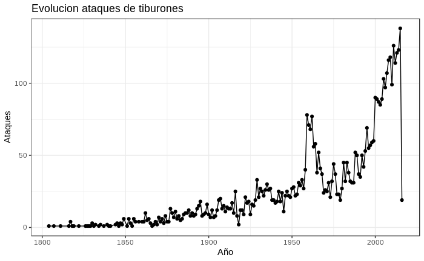

```r
ggplot(tiburones_filtro, aes(año)) +
  geom_line(stat = "count") +
  geom_point(stat='count') +
  theme_bw() +
  labs(title='Evolucion ataques de tiburones', x='Año', y='Ataques')
```

Seleccionamos a dos paises con muchos ataques. Recordemos que habiamos hecho algunos procedimientos de normalización sobre esta variable

```r
tiburones_aus_usa <- tiburones_filtro %>% filter(pais %in% c("AUSTRALIA","USA"))
```

Observemos el ciclo anual de ataques de tiburones en estos paises

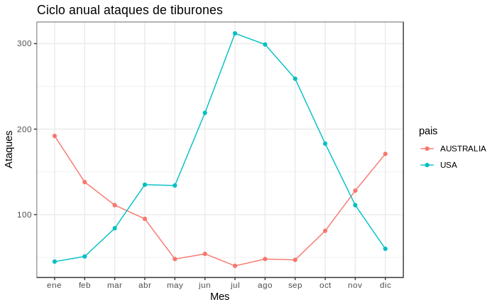

```r
ggplot(tiburones_aus_usa, aes(mes,color=pais, group=pais)) +
  geom_line(stat = "count") +
  geom_point(stat='count') +
  theme_bw() +
  labs(title='Ciclo anual ataques de tiburones', x='Mes', y='Ataques')
```